# Analisis Tesis

Juan Pablo Carranza Hurtado

July 22, 2019

Cargar base de datos de Trabajo de campo en formato CSV, utilizando “,” como el separador, y con headers como el nombre de las columnas

Caracterizacion de no respuesta

Creacion de dataframe para no respuesta

Caracterizacion general de no respuesta

```
## # A tibble: 3 x 3
##   noresp     n rfreq
##    <int> <int> <dbl>
## 1      1    65 0.227
## 2      2   114 0.399
## 3      3   107 0.374
```

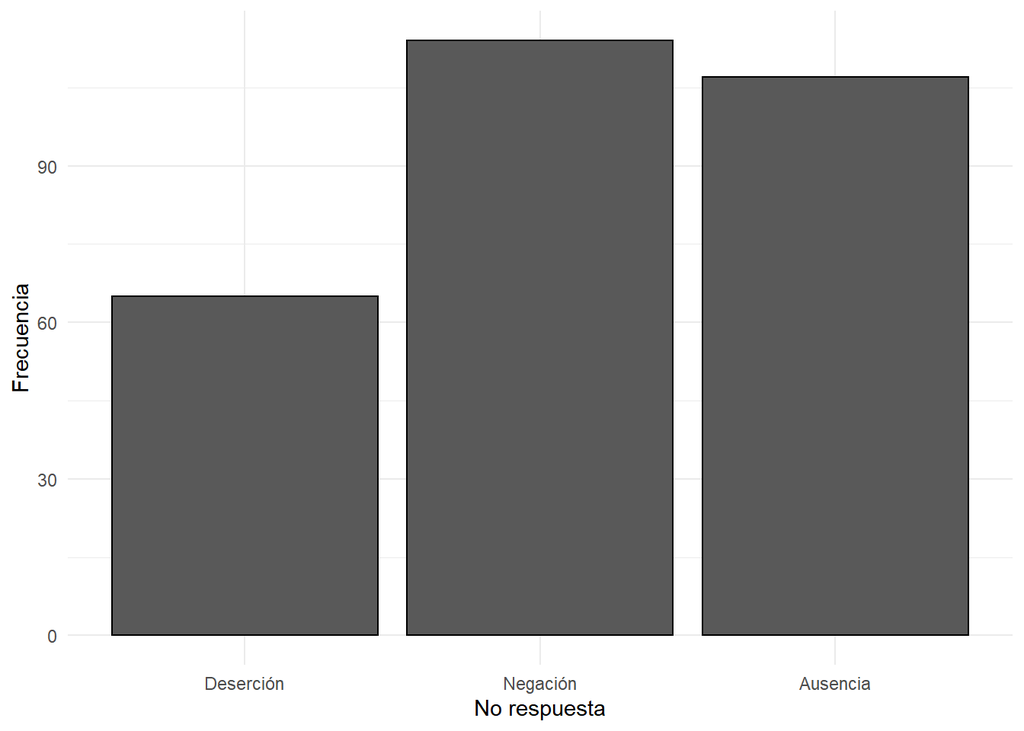

Caracterizacion por sexo de no respuesta:

```
## # A tibble: 6 x 4
## # Groups:   sexo [2]
##    sexo noresp     n rfreq
##   <int>  <int> <int> <dbl>
## 1     1      1    32 0.213
## 2     1      2    65 0.433
## 3     1      3    53 0.353
## 4     2      1    33 0.243
## 5     2      2    49 0.360
## 6     2      3    54 0.397
```

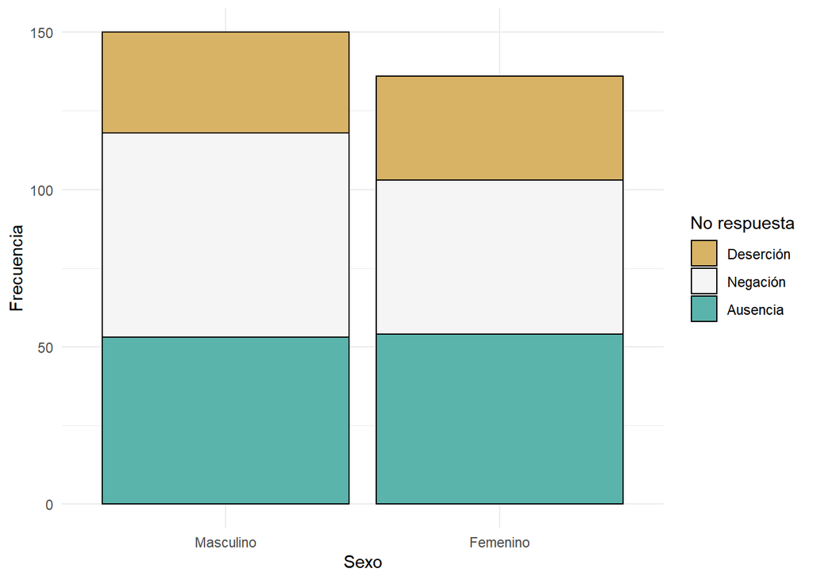

CaracterizaciÃ³n por edad de no respuesta

```
## # A tibble: 5 x 3
##    edad     n  rfreq
##   <int> <int>  <dbl>
## 1    12    18 0.0629
## 2    13    67 0.234
## 3    14    93 0.325
## 4    15    62 0.217
## 5    16    46 0.161
```

```
## # A tibble: 15 x 4
## # Groups:   edad [5]
##     edad noresp     n rfreq
##    <int>  <int> <int> <dbl>
##  1    12      1     7 0.389
##  2    12      2     6 0.333
##  3    12      3     5 0.278
##  4    13      1    13 0.194
##  5    13      2    27 0.403
##  6    13      3    27 0.403
##  7    14      1    14 0.151
##  8    14      2    47 0.505
##  9    14      3    32 0.344
## 10    15      1    17 0.274
## 11    15      2    24 0.387
## 12    15      3    21 0.339
## 13    16      1    14 0.304
## 14    16      2    10 0.217
## 15    16      3    22 0.478
```

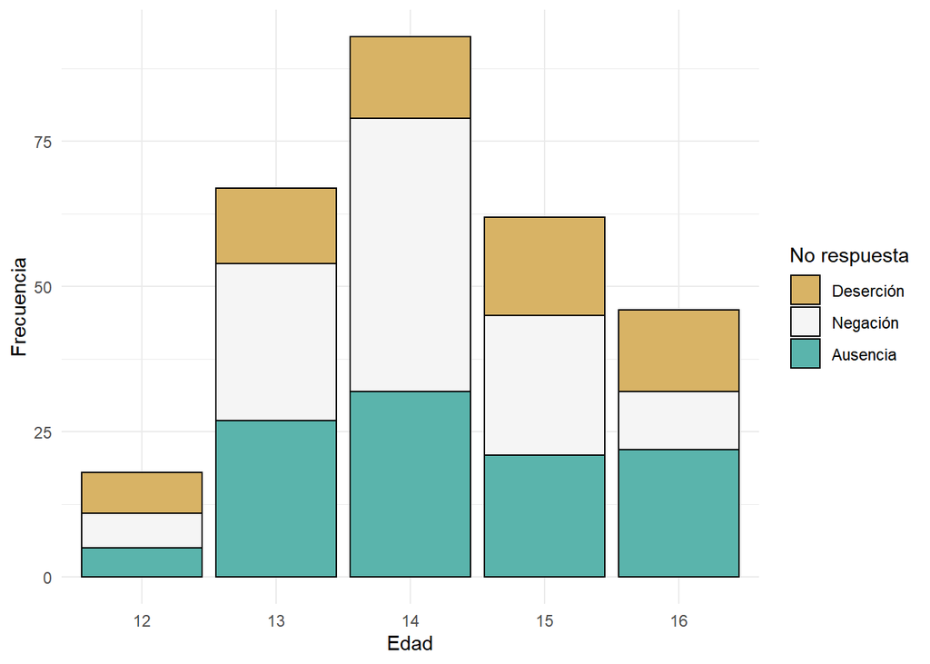

Caracterizacion por sector historico de no respuesta

```
## # A tibble: 3 x 3
##   sectorhist      n rfreq
##   <fct>       <int> <dbl>
## 1 COOPERATIVA    52 0.182
## 2 OFICIAL       147 0.514
## 3 PRIVADO        87 0.304
```

```
## # A tibble: 9 x 4
## # Groups:   sectorhist [3]
##   sectorhist  noresp     n rfreq
##   <fct>        <int> <int> <dbl>
## 1 COOPERATIVA      1     8 0.154
## 2 COOPERATIVA      2    25 0.481
## 3 COOPERATIVA      3    19 0.365
## 4 OFICIAL          1    35 0.238
## 5 OFICIAL          2    50 0.340
## 6 OFICIAL          3    62 0.422
## 7 PRIVADO          1    22 0.253
## 8 PRIVADO          2    39 0.448
## 9 PRIVADO          3    26 0.299
```

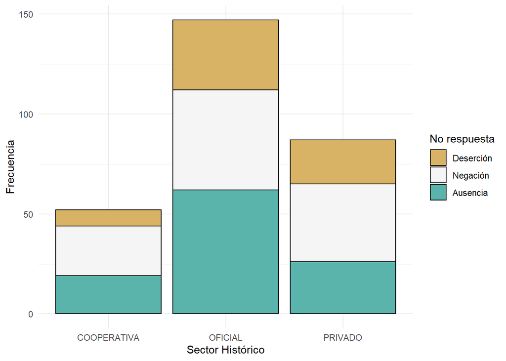

Caracterizacion por area historica de no respuesta

```
## # A tibble: 2 x 3
##   areahist     n rfreq
##   <fct>    <int> <dbl>
## 1 RURAL       97 0.339
## 2 URBANO     189 0.661
```

```
## # A tibble: 6 x 4
## # Groups:   areahist [2]
##   areahist noresp     n rfreq
##   <fct>     <int> <int> <dbl>
## 1 RURAL         1    17 0.175
## 2 RURAL         2    33 0.340
## 3 RURAL         3    47 0.485
## 4 URBANO        1    48 0.254
## 5 URBANO        2    81 0.429
## 6 URBANO        3    60 0.317
```

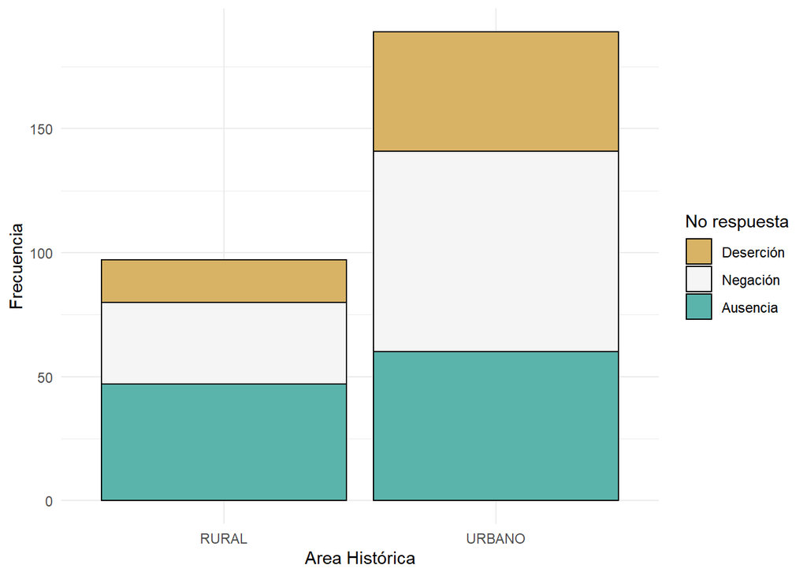

Caracterizacion por grado de no respuesta

```
## # A tibble: 3 x 3
##   grado     n rfreq
##   <int> <int> <dbl>
## 1     1   106 0.371
## 2     2   108 0.378
## 3     3    72 0.252
```

```
## # A tibble: 9 x 4
## # Groups:   grado [3]
##   grado noresp     n rfreq
##   <int>  <int> <int> <dbl>
## 1     1      1    32 0.302
## 2     1      2    32 0.302
## 3     1      3    42 0.396
## 4     2      1    16 0.148
## 5     2      2    48 0.444
## 6     2      3    44 0.407
## 7     3      1    17 0.236
## 8     3      2    34 0.472
## 9     3      3    21 0.292
```

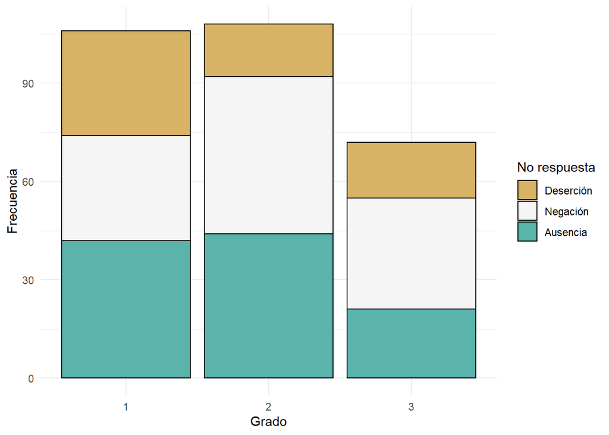

Creacion de data frame filtrando datos no vÃ¡lidos y ausentes

Tabla de frecuencias absolutas y relativas para cada una de las variables demográficas utilizadas en el estudio. Datos se encuentran excluidos. Sin poderación de datos, y a continuación de cada una con datos ponderados.

```
## # A tibble: 2 x 3
##    sexo     n rfreq
##   <int> <int> <dbl>
## 1     1   459 0.491
## 2     2   476 0.509
```

```
##         1         2
## 0.4857128 0.5142872
```

```
## # A tibble: 2 x 3
##   areahist     n rfreq
##   <fct>    <int> <dbl>
## 1 RURAL      492 0.526
## 2 URBANO     443 0.474
```

```
##     RURAL    URBANO
## 0.4810144 0.5189856
```

```
## # A tibble: 3 x 3
##   sectorhist      n rfreq
##   <fct>       <int> <dbl>
## 1 COOPERATIVA   163 0.174
## 2 OFICIAL       553 0.591
## 3 PRIVADO       219 0.234
```

```
## COOPERATIVA     OFICIAL     PRIVADO
##   0.1778962   0.5752159   0.2468879
```

```
## # A tibble: 3 x 3
##   grado     n rfreq
##   <int> <int> <dbl>
## 1     1   375 0.401
## 2     2   294 0.314
## 3     3   266 0.284
```

```
##         1         2         3
## 0.4012863 0.3174280 0.2812857
```

```
## # A tibble: 5 x 3
##   edada.os     n  rfreq
##      <int> <int>  <dbl>
## 1       12    50 0.0535
## 2       13   245 0.262
## 3       14   275 0.294
## 4       15   249 0.266
## 5       16   116 0.124
```

```
##         12         13         14         15         16
## 0.05684275 0.27027091 0.29404889 0.25971201 0.11912545
```

Cálculo de la proporción de estudiantes con sobrepeso y obesidad, a continuación de los datos corregidos

```
## # A tibble: 5 x 3
##   estnutri             n  rfreq
##   <fct>            <int>  <dbl>
## 1 Delgadez            21 0.0225
## 2 Delgadez extrema    11 0.0118
## 3 Normal             627 0.671
## 4 Obesidad           109 0.117
## 5 Sobrepeso          167 0.179
```

```
##         Delgadez Delgadez extrema           Normal         Obesidad
##       0.02107287       0.01135180       0.66000576       0.12509843
##        Sobrepeso
##       0.18247114
```

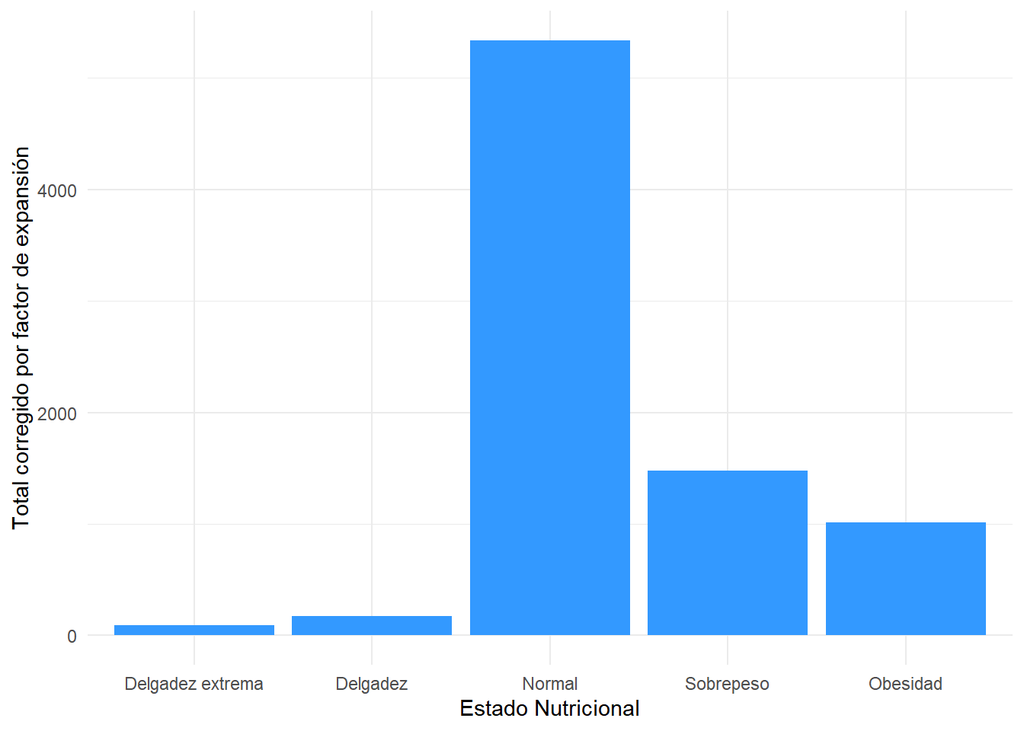

Calculo de la proporcion de estudiantes con sobrepeso y obesidad para sexo

```
## [1] "ProporciÃ³n ajustada de mujeres con sobrepeso y obesidad"
```

```
## Delgadez extrema         Delgadez           Normal        Sobrepeso
##       0.01004545       0.01955127       0.70066038       0.17753877
##         Obesidad
##       0.09220412
```

```
## [1] "ProporciÃ³n ajustada de hombres con sobrepeso y obesidad"
```

```
## Delgadez extrema         Delgadez           Normal        Sobrepeso
##       0.01273500       0.02268398       0.61695943       0.18769369
##         Obesidad
##       0.15992790
```

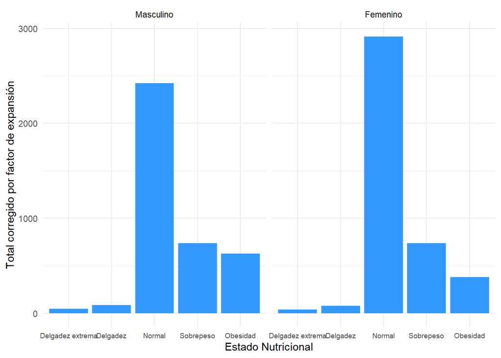

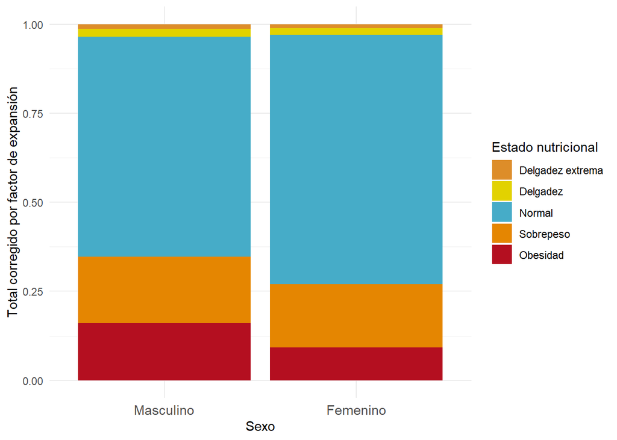

Calculo de la proporcion de estudiantes con sobrepeso y obesidad para area historica

```
## [1] "ProporciÃ³n ajustada de rural con sobrepeso y obesidad"
```

```
## Delgadez extrema         Delgadez           Normal        Sobrepeso
##      0.007952712      0.022638517      0.734140012      0.145573500
##         Obesidad
##      0.089695259
```

```
## [1] "ProporciÃ³n ajustada de urbano con sobrepeso y obesidad"
```

```
## Delgadez extrema         Delgadez           Normal        Sobrepeso
##       0.01450220       0.01962177       0.59129548       0.21666920
##         Obesidad
##       0.15791135
```

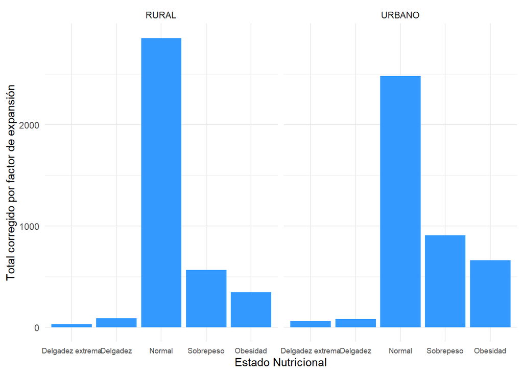

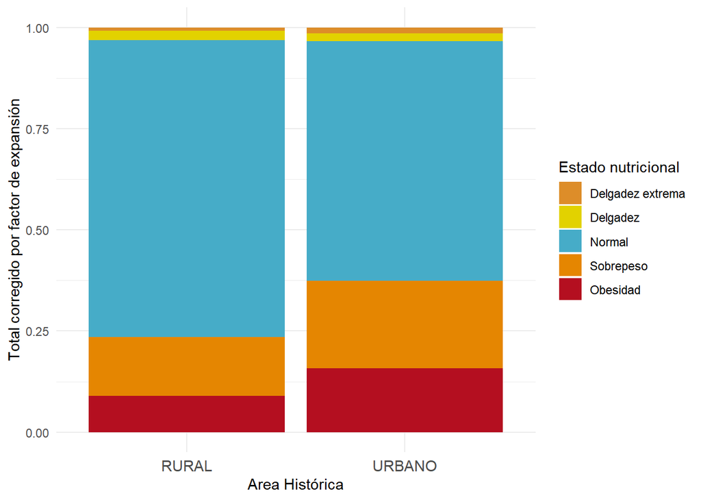

Calculo de la proporción de estudiantes con sobrepeso y obesidad para sector histórico

```
## [1] "ProporciÃ³n ajustada de oficial con sobrepeso y obesidad"
```

```
## Delgadez extrema         Delgadez           Normal        Sobrepeso
##       0.01330167       0.02199860       0.73045414       0.15188776
##         Obesidad
##       0.08235783
```

```
## [1] "ProporciÃ³n ajustada de cooperativa con sobrepeso y obesidad"
```

```
## Delgadez extrema         Delgadez           Normal        Sobrepeso
##       0.01009414       0.01061329       0.60955965       0.17952452
##         Obesidad
##       0.19020839
```

```
## [1] "ProporciÃ³n ajustada de privado con sobrepeso y obesidad"
```

```
## Delgadez extrema         Delgadez           Normal        Sobrepeso
##      0.007715089      0.026452736      0.532219615      0.255849541
##         Obesidad
##      0.177763019
```

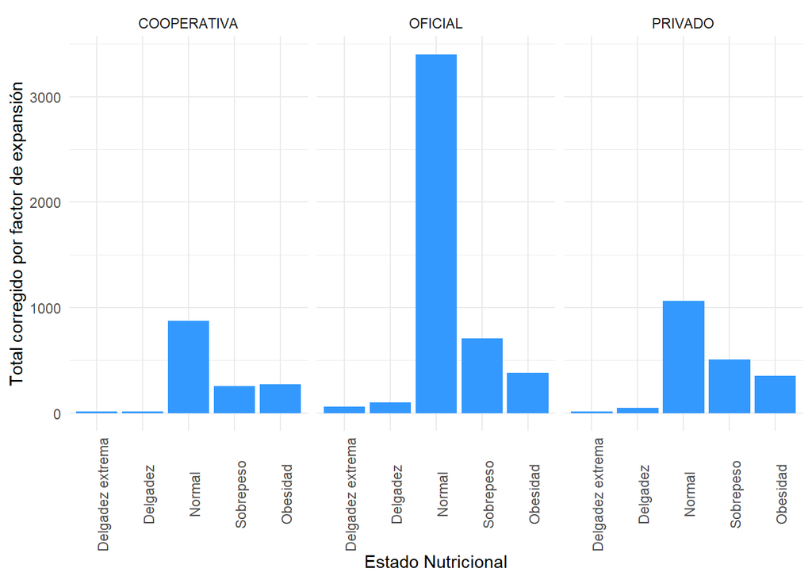

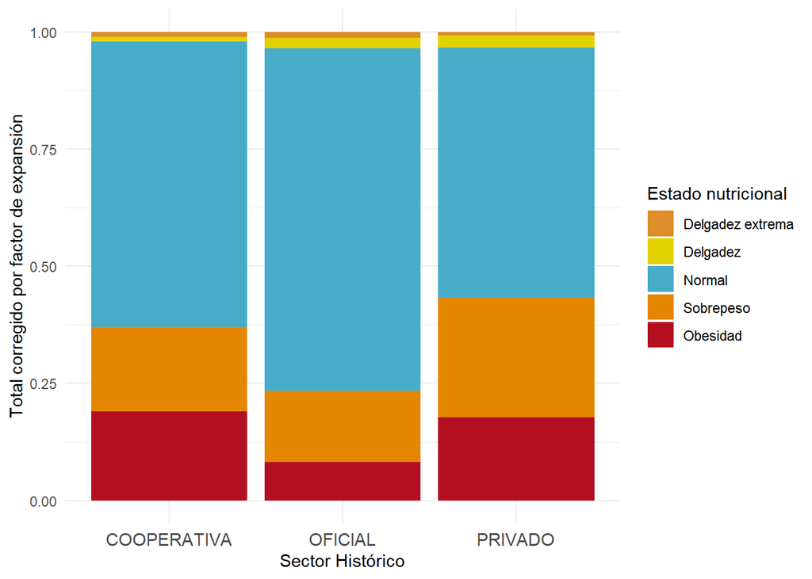

Calculo de la proporciÃ³n de estudiantes con sobrepeso y obesidad para grado

```
## [1] "ProporciÃ³n ajustada de 1ero con sobrepeso y obesidad"
```

```
## Delgadez extrema         Delgadez           Normal        Sobrepeso
##       0.01430462       0.02520825       0.64143960       0.18687620
##         Obesidad
##       0.13217133
```

```
## [1] "ProporciÃ³n ajustada de 2do con sobrepeso y obesidad"
```

```
## Delgadez extrema         Delgadez           Normal        Sobrepeso
##      0.006439398      0.016340994      0.687621846      0.151480018
##         Obesidad
##      0.138117744
```

```
## [1] "ProporciÃ³n ajustada de 3ero con sobrepeso y obesidad"
```

```
## Delgadez extrema         Delgadez           Normal        Sobrepeso
##       0.01268286       0.02051315       0.65532804       0.21115999
##         Obesidad
##       0.10031595
```

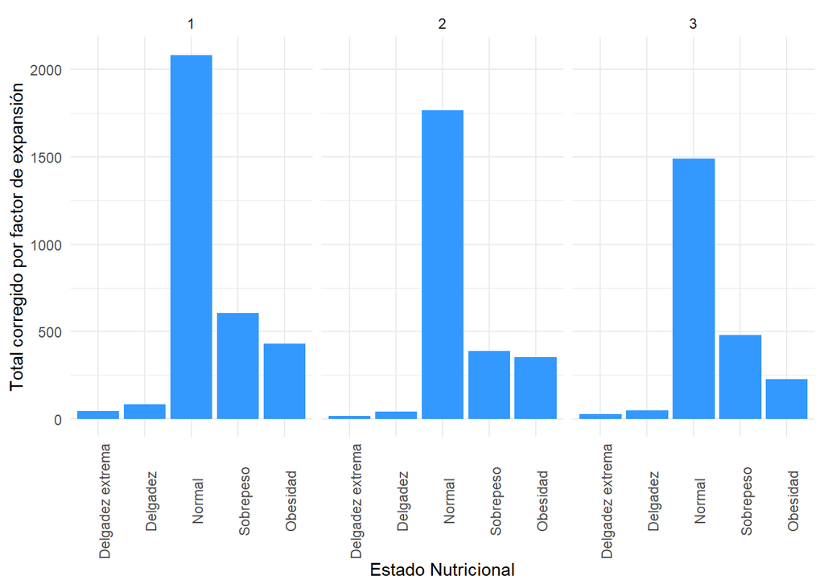

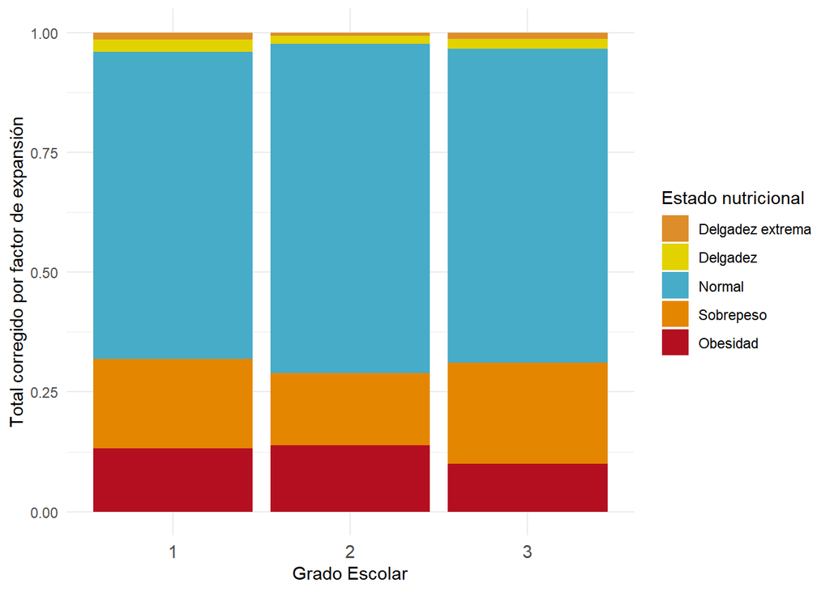

```
## [1] "ProporciÃ³n ajustada de 12 con sobrepeso y obesidad"
```

```
##   Delgadez     Normal  Sobrepeso   Obesidad
## 0.03402677 0.54272951 0.18220024 0.24104349
```

```
## [1] "ProporciÃ³n ajustada de 13 con sobrepeso y obesidad"
```

```
## Delgadez extrema         Delgadez           Normal        Sobrepeso
##       0.02123887       0.01837164       0.59901177       0.20747589
##         Obesidad
##       0.15390183
```

```
## [1] "ProporciÃ³n ajustada de 14 con sobrepeso y obesidad"
```

```
## Delgadez extrema         Delgadez           Normal        Sobrepeso
##      0.003238853      0.014160856      0.686525647      0.174128494
##         Obesidad
##      0.121946150
```

```
## [1] "ProporciÃ³n ajustada de 15 con sobrepeso y obesidad"
```

```
## Delgadez extrema         Delgadez           Normal        Sobrepeso
##       0.01793977       0.02187891       0.71230729       0.16032372
##         Obesidad
##       0.08755031
```

```
## [1] "ProporciÃ³n ajustada de 16 con sobrepeso y obesidad"
```

```
##   Delgadez     Normal  Sobrepeso   Obesidad
## 0.03632452 0.67486173 0.19474764 0.09406611
```

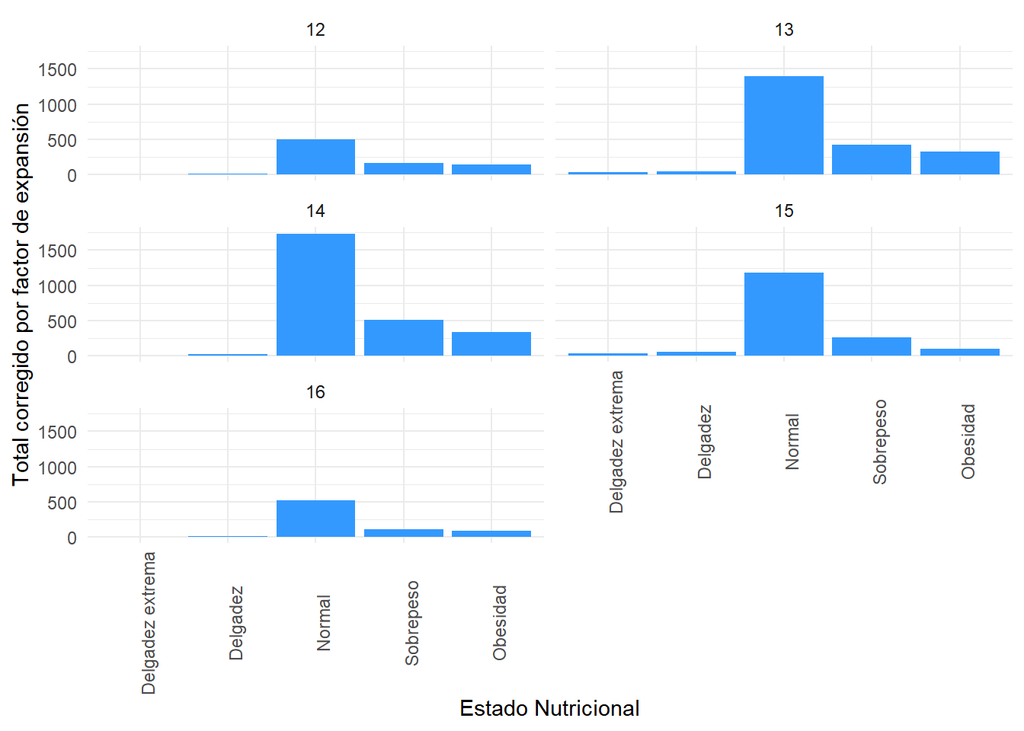

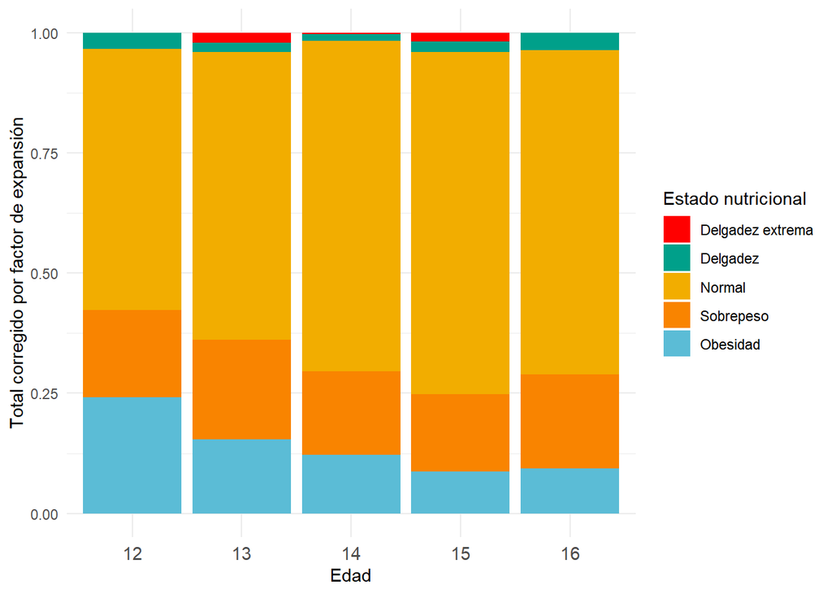

ANALISIS DE DATOS CUANTITATIVOS:

Para iniciar el analisis de datos cuantitativos se utilizara una representacion grafica de las variables cuantitativas del estudio. Se iniciara creando histogramas para la representacion de las distribuciones del puntaje z para cada variable sociodemografica.

ANALISIS GRAFICO DE PUNTAJE Z

Histograma Y QQPLOT de distribucion general de puntaje z

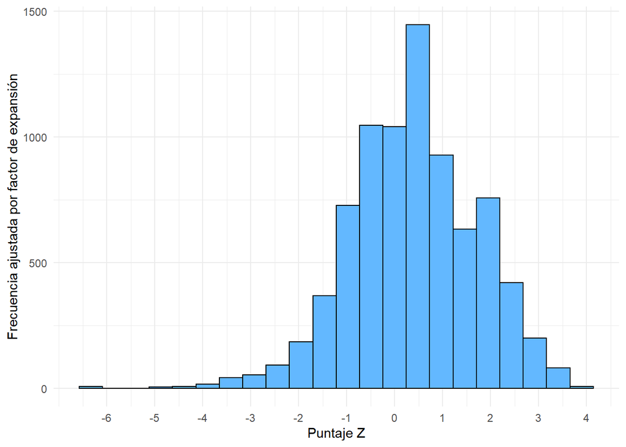

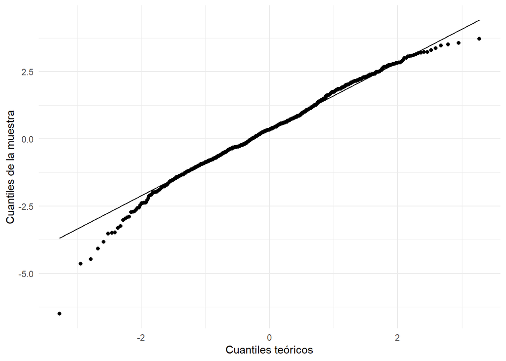

Histograma Y QQPLOT de distribucion de puntaje z para sexo

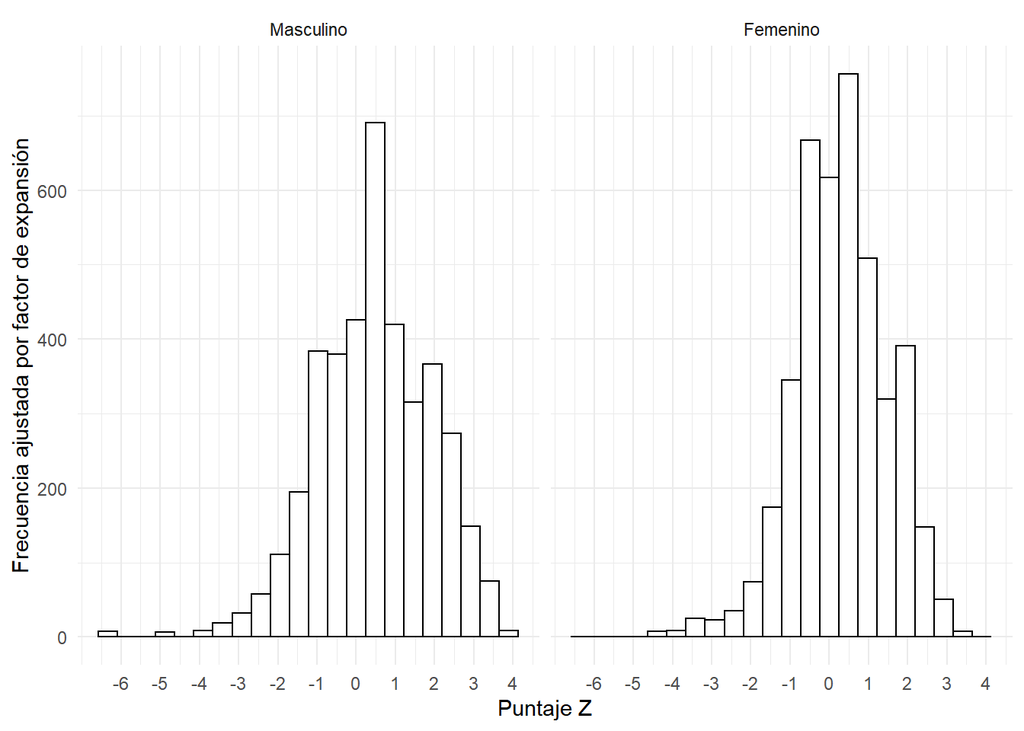

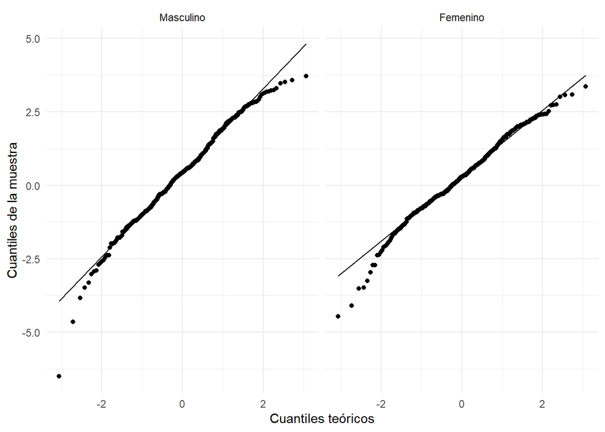

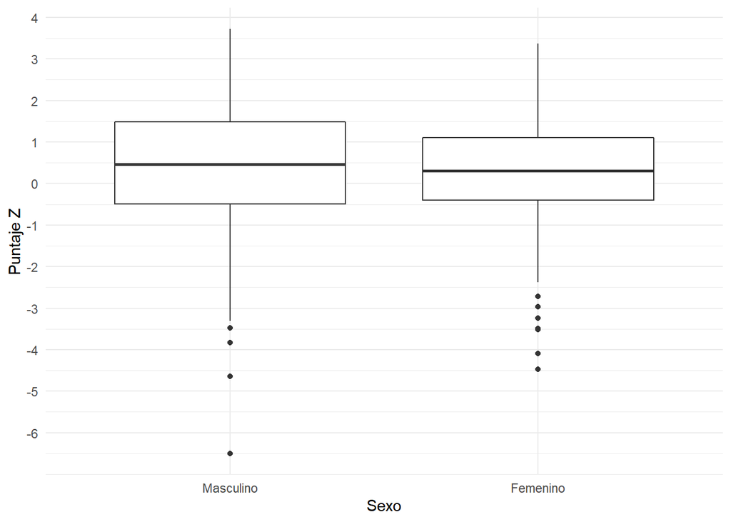

Histograma y QQPLOT de distribucion de puntaje z para area historica

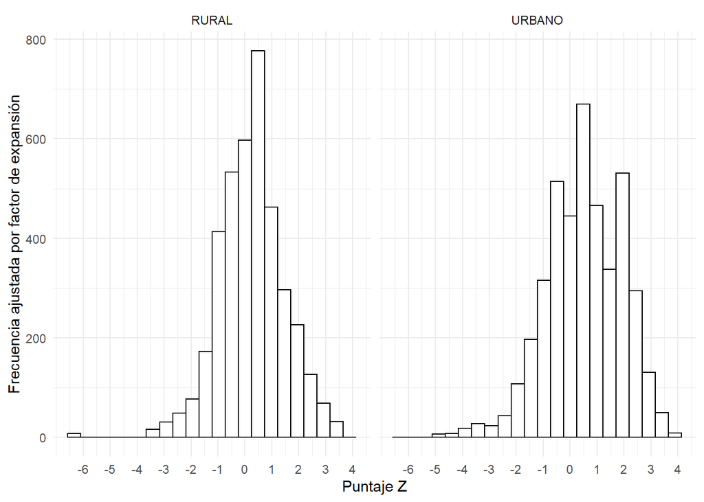

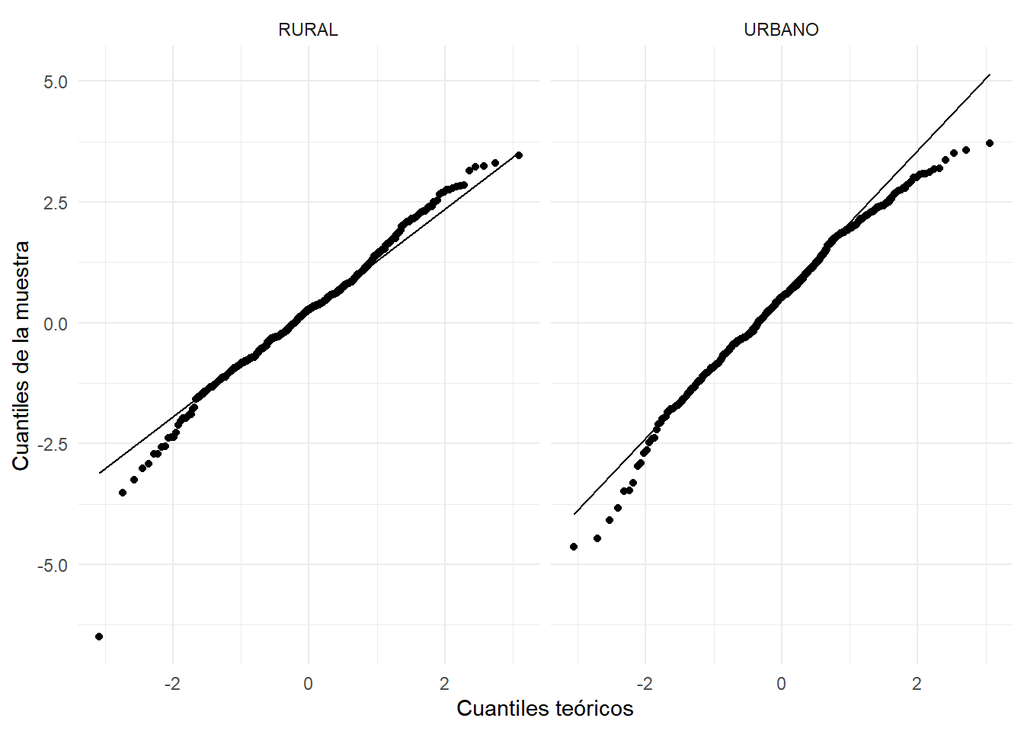

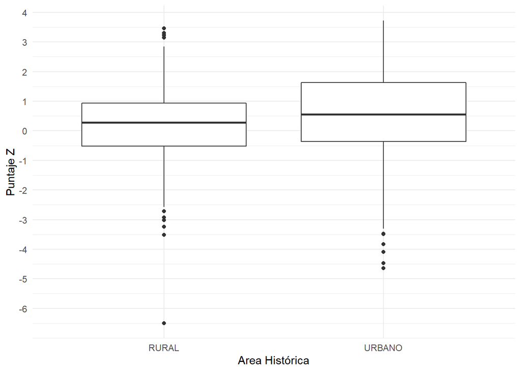

Histograma y QQPLOT de distribucion de puntaje z para sector historico

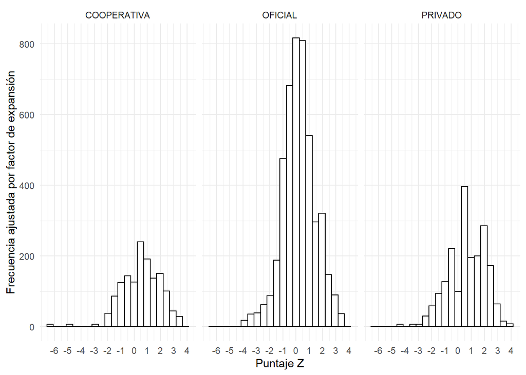

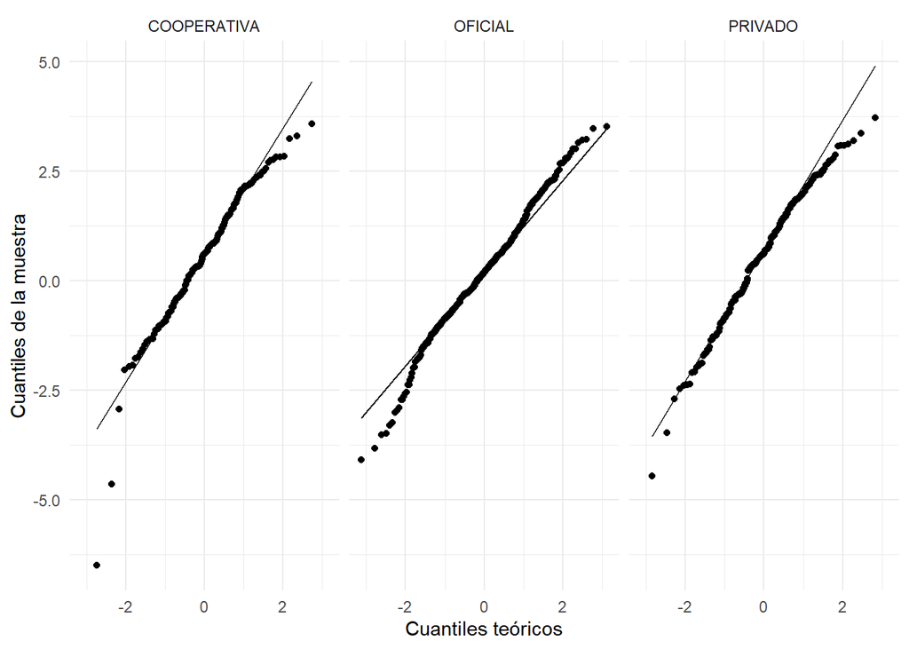

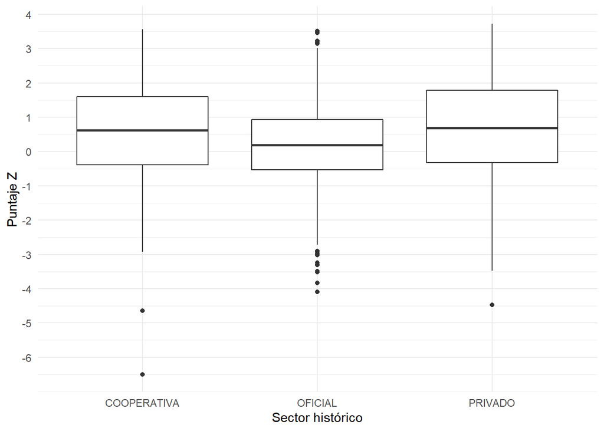

Histograma y QQPLOT de distribucion de puntaje z para grado

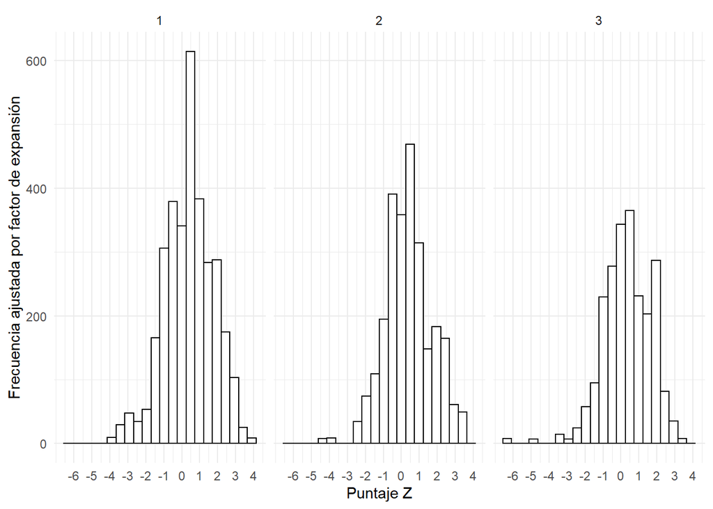

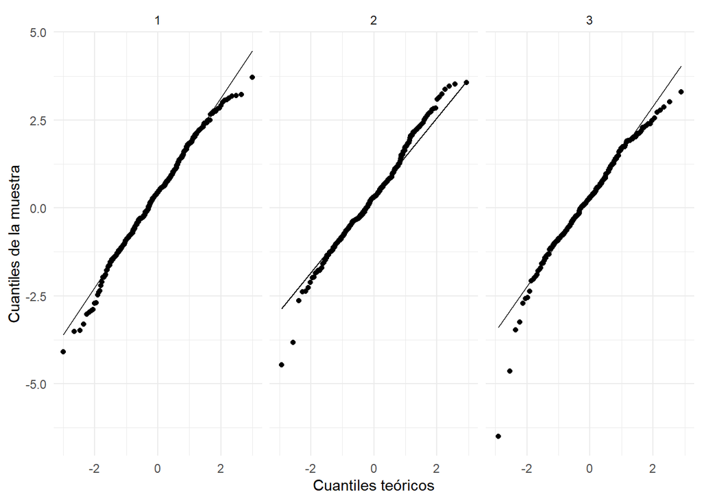